# the starteR pack

1/12/2021

## The “What” and “Why” of R: a refresher

**R is a language**  
Why code?

**Efficiency**

Accuracy

Reproducibility

## Efficiency

[figure not shown]

## We’re a team

- Accurate : fewer opportunities for error
- Reproducible: all doing the same thing - transferrable
- Efficient: save time for everyone

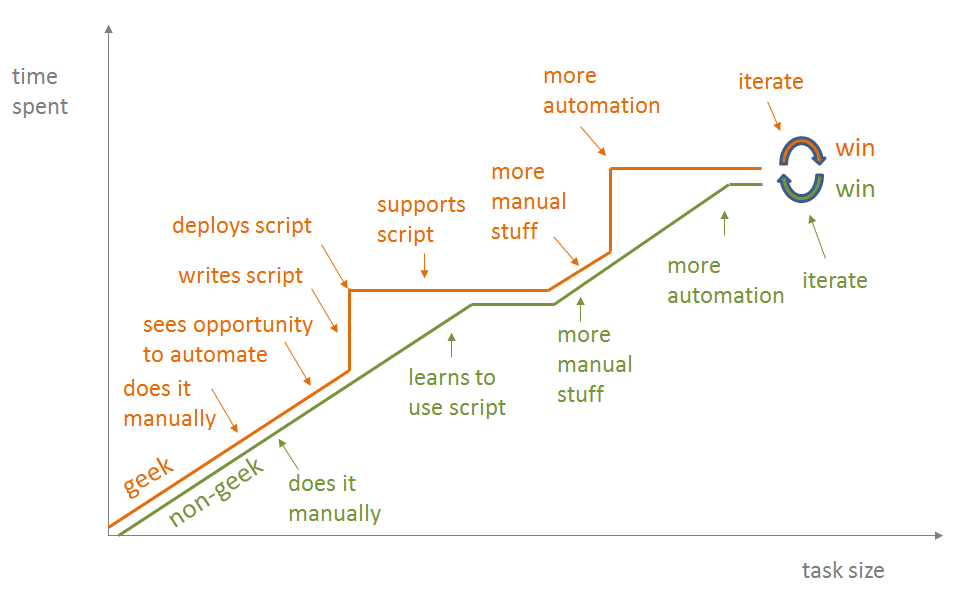

  https://blog.jonudell.net/2012/01/09/another-way-to-think-about-geeks-and-repetitive-tasks/

## Is it worth it?

[figure not shown]

## Different types of products

- Powerful data viz  
  [The R Graph Gallery](https://www.r-graph-gallery.com/index.html)
- Reproducible figures and reports  
  [The R Markdown Gallery](https://rmarkdown.rstudio.com/gallery.html)
- Interactive documents web apps (Shiny) [West Coast Groundfish Bottom Trawl Survey Catch Data](https://erickabsmith.shinyapps.io/catch-data/)

## What are we covering today?

- Intro to R & Rstudio  
  [The Rstudio environment](https://r4ds.had.co.nz/workflow-scripts.html)
- Troubleshooting & Finding Help  
  [You’re not alone!](https://stackoverflow.com/questions/tagged/r)
- Coding Etiquette  
  [Best Scripting Practices](https://emilymarkowitz-noaa.github.io/RWorkshopForSocialScientists/les_BestScriptingPractices.nb.html)

## Our Coding Club tutorials platform

[University of Edinburgh Coding Club Data Science Course](https://ourcodingclub.github.io/)

## Goals for these three days:

By the time you’ve finished this sessions you’ll…

- be aware of R applications that might be helpful in your work
- be able to import a data file and perform basic manipulations
- know where to go to answer your questions & learn new skills
- feel comfortable working in the R environment
- have a cohort of peers you can turn to!

## Let’s get started!

Head over to the first tutorial linked in the [agenda](https://chanteddavis-noaa.github.io/WCR_RStarterPack/sessions.html)  
Message Chante or Diana if you need help  
Reconvene at **10am** for challenge & quiz